# Assignment 1

Manning Smith

9/9/2024

# Prompt

1. structure of the data set, including length, data type, names, and the components of the data set.
2. Average Measures for continuous variables, including Mean, Median, Standard deviation, Variance, Median Absolute Variance (deviation), maximum, Minimum, and Sum.
3. Frequency for categorical variables.
4. Plots of summary statistics (such as histograms or bar-plot) for one continuous variable and categorical variable respectively.

# Data Set Information

- PatientID: unique patient identifier
- Age: age in years
- Sex: 1 = male; 0 = female
- ChestPain: chest pain type
- RestBP: resting blood pressure (in mm Hg on admission to the hospital)
- Chol: serum cholestoral in mg/dl
- Fbs: fasting blood sugar > 120 mg/dl (1 = true; 0 = false)
- RestECG: resting electrocardiographic results. 0: normal ; 1: having ST-T wave abnormality (T wave inversions and/or ST elevation or depression of > 0.05 mV) ; 2: showing probable or definite left ventricular hypertrophy by Estes’ criteria.
- MaxHR: maximum heart rate achieved
- ExAng: exercise induced angina (1 = yes; 0 = no)
- Oldpeak: ST depression induced by exercise relative to rest
- Slope: the slope of the peak exercise ST segment. 1: upsloping; 2: flat; 3: downsloping
- Ca: number of major vessels (0-3) colored by flourosopy
- Thal: Thallium stress test, 3 =normal; 6 = fixed (defect); 7 = reversable (defect)
- AHD (the predicted attribute): angiographic heart disease

# Import Data

```r
Heart <- read.csv("Heart.csv")

#View(Heart)
```

Upon the initial look of the data set it contains information related to patient heart data. Both sex and age are provided. The sex of the patient is provided by (1,0), but information is given that 1 is male and 0 is female. There are some NA values for the ‘Ca’ variable, but this should not affect the data set. Overall, the data set looks pretty good to proceed with.

# Question 1 | Structure

```r
# Structure Function
str(Heart)
```

```
## 'data.frame':    303 obs. of  15 variables:
##  $ PatientID: int  1 2 3 4 5 6 7 8 9 10 ...
##  $ Age      : int  63 67 67 37 41 56 62 57 63 53 ...
##  $ Sex      : int  1 1 1 1 0 1 0 0 1 1 ...
##  $ ChestPain: chr  "typical" "asymptomatic" "asymptomatic" "nonanginal" ...
##  $ RestBP   : int  145 160 120 130 130 120 140 120 130 140 ...
##  $ Chol     : int  233 286 229 250 204 236 268 354 254 203 ...
##  $ Fbs      : int  1 0 0 0 0 0 0 0 0 1 ...
##  $ RestECG  : int  2 2 2 0 2 0 2 0 2 2 ...
##  $ MaxHR    : int  150 108 129 187 172 178 160 163 147 155 ...
##  $ ExAng    : int  0 1 1 0 0 0 0 1 0 1 ...
##  $ Oldpeak  : num  2.3 1.5 2.6 3.5 1.4 0.8 3.6 0.6 1.4 3.1 ...
##  $ Slope    : int  3 2 2 3 1 1 3 1 2 3 ...
##  $ Ca       : int  0 3 2 0 0 0 2 0 1 0 ...
##  $ Thal     : chr  "fixed" "normal" "reversable" "normal" ...
##  $ AHD      : chr  "No" "Yes" "Yes" "No" ...
```

```r
# Column names
cols <- colnames(Heart)
#print(cols)
```

The structure of the data set can be seen above. There are 303 observations and 15 variables, most of the variables are integers, but there is one ID variable, 3 characters variable, and one numerical (meaning there are decimals).

*Continuous Variables:*  
`Age`, `RestBP`, `Chol`, `MaxHR`, `OldPeak`

*Categorical Variables:*  
`ChestPain`, `RestECG`, `Slope`, `Ca`, `Thal`, `AHD`

`ChestPain` is a categorical data point with the options of: ‘typical’, ‘asymptomatic’, ‘nonanginal’, and ‘nontypical’.

`Thal` stands for Thallium stress test is also a categorical data point with the options of: ‘fixed’, ‘normal’, and ‘reversible’.

`AHD` is a YES/NO binary data point.

*Binary Variables:*  
`Sex`, `Fbs`, `ExAng`

# Question 2 | Summary Statistics

```r
# Select all numerical data points
continuous_vars <- c("Age", "RestBP", "Chol", "MaxHR", "Oldpeak")

# Provide Summary
#summary(Heart)

# Group all results in a dataframe

summary_stats <- data.frame(
  Mean = sapply(Heart[continuous_vars], mean, na.rm = TRUE), # Mean
  Median = sapply(Heart[continuous_vars], median, na.rm = TRUE), # Median
  Std_Dev = sapply(Heart[continuous_vars], sd, na.rm = TRUE), # Standard deviation
  Variance = sapply(continuous_vars, function(x) var(Heart[[x]], na.rm = TRUE)), # Variance
  MAD = sapply(Heart[continuous_vars], mad, na.rm = TRUE), # Median
  Min = sapply(Heart[continuous_vars], min, na.rm = TRUE), # Minimum
  Max = sapply(Heart[continuous_vars], max, na.rm = TRUE), # Maximum
  Sum = sapply(Heart[continuous_vars], sum, na.rm = TRUE) # Sum
)

# Print Pretty Table
kable(summary_stats, caption = "Summary Statistics for Continuous Variables", digits = 5)
```

Summary Statistics for Continuous Variables

|  | Mean | Median | Std_Dev | Variance | MAD | Min | Max | Sum |
| --- | --- | --- | --- | --- | --- | --- | --- | --- |
| Age | 54.43894 | 56.0 | 9.03866 | 81.69742 | 8.89560 | 29 | 77.0 | 16495 |
| RestBP | 131.68977 | 130.0 | 17.59975 | 309.75112 | 14.82600 | 94 | 200.0 | 39902 |
| Chol | 246.69307 | 241.0 | 51.77692 | 2680.84919 | 47.44320 | 126 | 564.0 | 74748 |
| MaxHR | 149.60726 | 153.0 | 22.87500 | 523.26577 | 22.23900 | 71 | 202.0 | 45331 |
| Oldpeak | 1.03960 | 0.8 | 1.16108 | 1.34810 | 1.18608 | 0 | 6.2 | 315 |

# Question 3 | Frequency

```r
# Select all categorical data points
categorical_vars <- c("Sex", "ChestPain", "Fbs", "RestECG", "ExAng", "Slope", "Ca", "Thal", "AHD")

freq_tables1 <- lapply(Heart[categorical_vars[1]], table)
kable(freq_tables1, caption = "Frequency Table for Sex", digits = 2)
```

Frequency Table for Sex

| Var1 | Freq |
| --- | --- |
| 0 | 97 |
| 1 | 206 |

```r
freq_tables2 <- lapply(Heart[categorical_vars[2]], table)
kable(freq_tables2, caption = "Frequency Table for Chest Pain", digits = 2)
```

Frequency Table for Chest Pain

| Var1 | Freq |
| --- | --- |
| asymptomatic | 144 |
| nonanginal | 86 |
| nontypical | 50 |
| typical | 23 |

```r
freq_tables3 <- lapply(Heart[categorical_vars[3]], table)
kable(freq_tables3, caption = "Frequency Table for Fasting Blood Sugar", digits = 2)
```

Frequency Table for Fasting Blood Sugar

| Var1 | Freq |
| --- | --- |
| 0 | 258 |
| 1 | 45 |

```r
freq_tables4 <- lapply(Heart[categorical_vars[4]], table)
kable(freq_tables4, caption = "Frequency Table for Resting Electrocardiographic Result", digits = 2)
```

Frequency Table for Resting Electrocardiographic Result

| Var1 | Freq |
| --- | --- |
| 0 | 151 |
| 1 | 4 |
| 2 | 148 |

```r
freq_tables5 <- lapply(Heart[categorical_vars[5]], table)
kable(freq_tables5, caption = "Frequency Table for Exercise Induced Angina", digits = 2)
```

Frequency Table for Exercise Induced Angina

| Var1 | Freq |
| --- | --- |
| 0 | 204 |
| 1 | 99 |

```r
freq_tables6 <- lapply(Heart[categorical_vars[6]], table)
kable(freq_tables6, caption = "Frequency Table for Slope", digits = 2)
```

Frequency Table for Slope

| Var1 | Freq |
| --- | --- |
| 1 | 142 |
| 2 | 140 |
| 3 | 21 |

```r
freq_tables7 <- lapply(Heart[categorical_vars[7]], table)
kable(freq_tables7, caption = "Frequency Table for Number of Vessels", digits = 2)
```

Frequency Table for Number of Vessels

| Var1 | Freq |
| --- | --- |
| 0 | 176 |
| 1 | 65 |
| 2 | 38 |
| 3 | 20 |

```r
freq_tables8 <- lapply(Heart[categorical_vars[8]], table)
kable(freq_tables8, caption = "Frequency Table for Thallium Stress Test", digits = 2)
```

Frequency Table for Thallium Stress Test

| Var1 | Freq |
| --- | --- |
| fixed | 18 |
| normal | 166 |
| reversable | 117 |

```r
freq_tables9 <- lapply(Heart[categorical_vars[9]], table)
kable(freq_tables9, caption = "Frequency Table for AHD", digits = 2)
```

Frequency Table for AHD

| Var1 | Freq |
| --- | --- |
| No | 164 |
| Yes | 139 |

# Question 4 | Plots

## Continuous

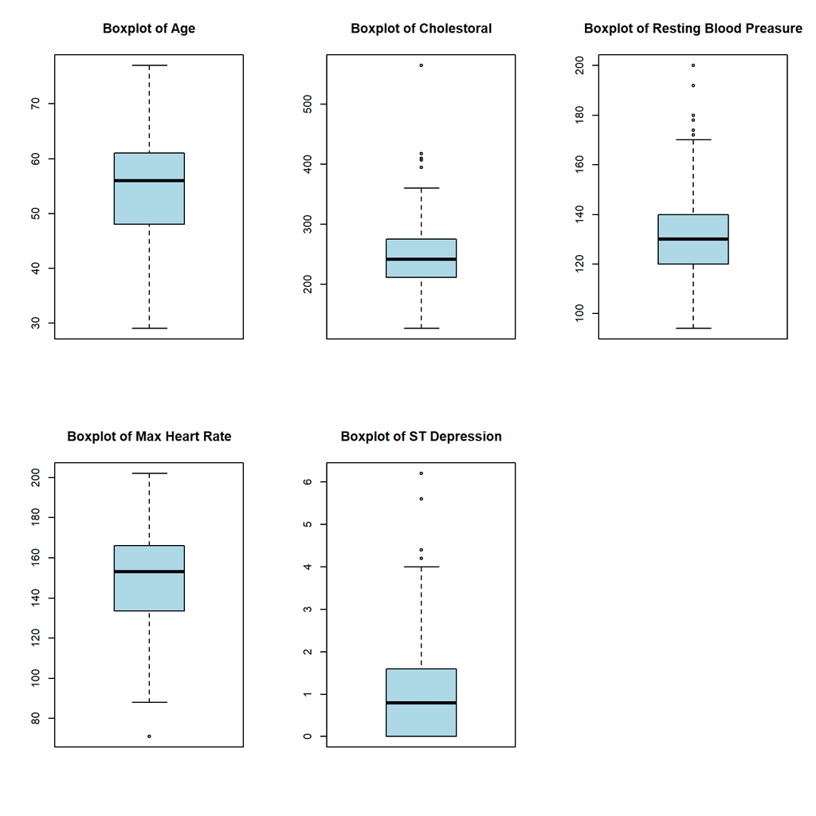

```r
par(mfrow = c(2, 3))

# Age
#hist(Heart$Age, main = "Histogram of Age", xlab = "Age", col = "lightblue", border = "black")
boxplot(Heart$Age, main = "Boxplot of Age", col = "lightblue", border = "black", horizontal = FALSE)

# Chol
#hist(Heart$Chol, main = "Histogram of Cholestoral", xlab = "Cholestoral", col = "lightblue", border = "black")
boxplot(Heart$Chol, main = "Boxplot of Cholestoral", col = "lightblue", border = "black", horizontal = FALSE)

# RestBP
#hist(Heart$RestBP, main = "Histogram of Resting Blood Preasure", xlab = "RestBP", col = "lightblue", border = "black")
boxplot(Heart$RestBP, main = "Boxplot of Resting Blood Preasure", col = "lightblue", border = "black", horizontal = FALSE)

# MaxHR
#hist(Heart$MaxHR, main = "Histogram of Max Heart Rate", xlab = "MaxHR", col = "lightblue", border = "black")
boxplot(Heart$MaxHR, main = "Boxplot of Max Heart Rate", col = "lightblue", border = "black", horizontal = FALSE)


# Oldpeak
#hist(Heart$Oldpeak, main = "Histogram of ST Depression", xlab = "Oldpeak", col = "lightblue", border = "black")
boxplot(Heart$Oldpeak, main = "Boxplot of ST Depression", col = "lightblue", border = "black", horizontal = FALSE)
```

The `Age` variable is normally distributed between ages 29 and 77 with no apparent outliers.  
The `Chol` variable is normally distributed with a few outliers on the higher end.  
The `RestBP` variable is normally distributed with a few outliers on the higher end.  
The `MaxHR` variable is normally distributed with one outlier on the low end.  
The `Oldpeak` variable is right skewed with most of the data falling between 0 & 2 with data points as far as 6.

## Categorical

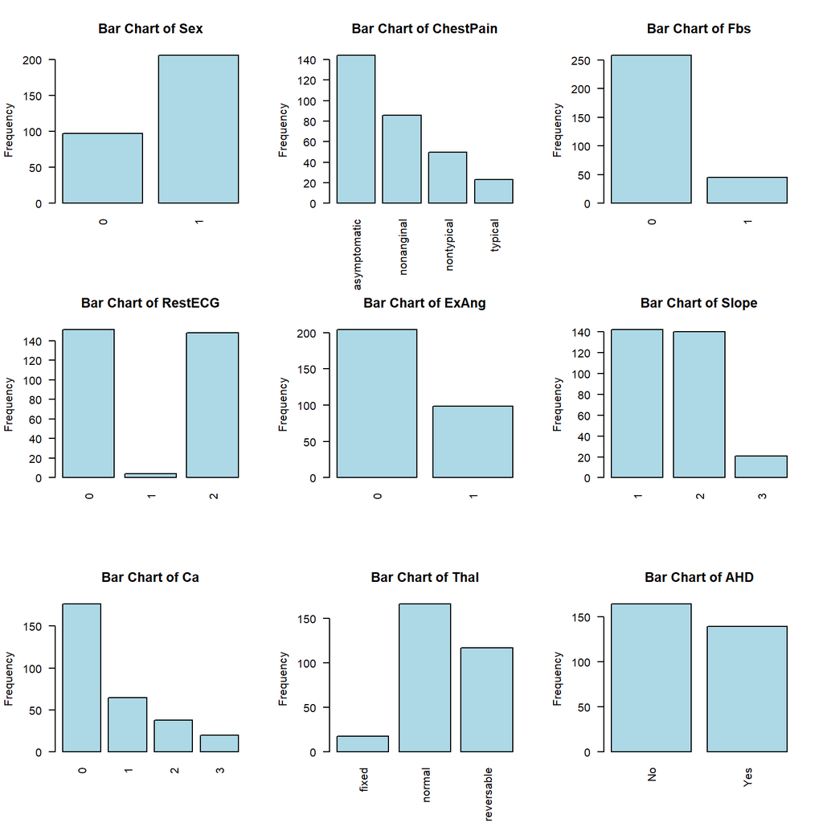

```r
par(mfrow = c(3, 3))

freq_tables <- lapply(Heart[categorical_vars], table)

plot_bar_chart <- function(variable) {
  freq_table <- table(Heart[[variable]])
  barplot(freq_table, main = paste("Bar Chart of", variable), col = "lightblue", border = "black",
          ylab = "Frequency", las = 2)
}

# Plot bar charts for each categorical variable
for (var in categorical_vars)
  plot_bar_chart(var)
```

The data set contains twice as many data points for males than females. This could be an issue when using all the data to predict female outcomes. You may only be able to generalize based on the subset gender populations.

## Factor by Sex

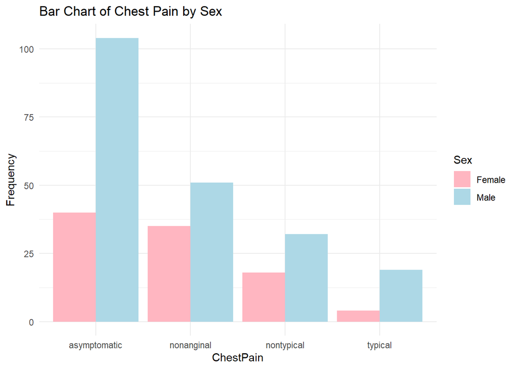

```r
Heart$Sex <- factor(Heart$Sex, levels = c(0, 1), labels = c("Female", "Male"))

ggplot(Heart, aes(x = ChestPain, fill = Sex)) +
    geom_bar(position = "dodge") +
    labs(title = "Bar Chart of Chest Pain by Sex", x = "ChestPain", y = "Frequency") +
    scale_fill_manual(values = c("Female" = "lightpink", "Male" = "lightblue")) +
    theme_minimal()
```

# Personal Exploration

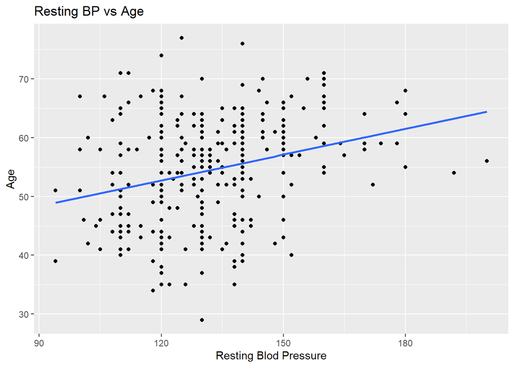

```r
ggplot(Heart, aes(x = RestBP, y = Age)) +
  geom_point() +
  labs(x = "Resting Blod Pressure", y = "Age", title = "Resting BP vs Age") +
  geom_smooth(method = "lm", se = FALSE)
```

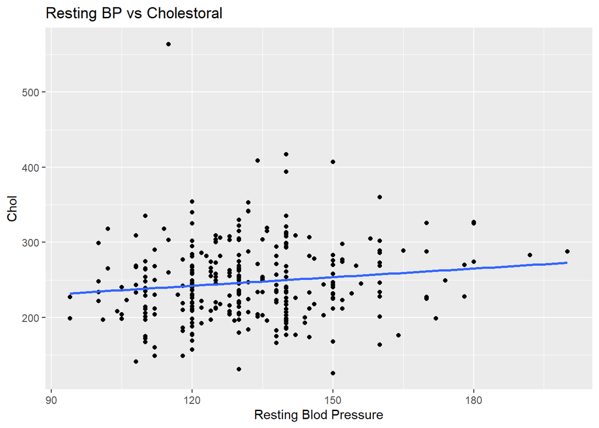

```r
ggplot(Heart, aes(x = RestBP, y = Chol)) +
  geom_point() +
  labs(x = "Resting Blod Pressure", y = "Chol", title = "Resting BP vs Cholestoral") +
  geom_smooth(method = "lm", se = FALSE)
```

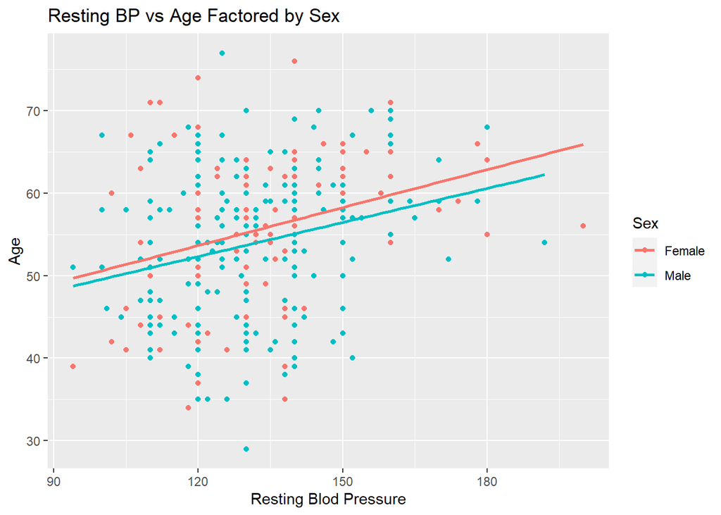

```r
ggplot(Heart, aes(x = RestBP, y = Age, color = Sex)) +
  geom_point() +
  labs(x = "Resting Blod Pressure", y = "Age", colored = "Sex", title = "Resting BP vs Age Factored by Sex") +
  geom_smooth(method = "lm", se = FALSE)
```

[figure not shown]

```r
ggplot(Heart, aes(x = RestBP, y = MaxHR, color = ChestPain)) +
  geom_point() +
  labs(x = "Resting Blod Pressure", y = "Max HR", colored = "Sex", title = "Resting BP vs Age Factored by Sex") +
  geom_smooth(method = "lm", se = FALSE)
```

```r
model1_Sex <- lm(RestBP ~ Age * Sex, data = Heart)
model2_Chol <- lm(RestBP ~ Age * Sex * Chol, data = Heart)
model3_ChestPain <- lm(RestBP ~ Age * ChestPain, data = Heart)
model4 <- glm(ExAng ~ RestBP + Sex + Chol, data = Heart, family = binomial)
model5 <- glm(Sex ~ RestBP + Chol, data = Heart, family = binomial)



model1_Sex
```

```
##
## Call:
## lm(formula = RestBP ~ Age * Sex, data = Heart)
##
## Coefficients:
## (Intercept)          Age      SexMale  Age:SexMale
##     96.8103       0.6556       7.6663      -0.1645
```

```r
model2_Chol
```

```
##
## Call:
## lm(formula = RestBP ~ Age * Sex * Chol, data = Heart)
##
## Coefficients:
##      (Intercept)               Age           SexMale              Chol
##        61.873303          1.130528        -14.077019          0.157034
##      Age:SexMale          Age:Chol      SexMale:Chol  Age:SexMale:Chol
##         0.328677         -0.002213          0.084661         -0.001905
```

```r
model3_ChestPain
```

```
##
## Call:
## lm(formula = RestBP ~ Age * ChestPain, data = Heart)
##
## Coefficients:
##             (Intercept)                      Age      ChestPainnonanginal
##                110.8608                   0.3830                  -9.5956
##     ChestPainnontypical         ChestPaintypical  Age:ChestPainnonanginal
##                -18.4398                 -16.2238                   0.1576
## Age:ChestPainnontypical     Age:ChestPaintypical
##                  0.3175                   0.4445
```

```r
summary (model4)
```

```
##
## Call:
## glm(formula = ExAng ~ RestBP + Sex + Chol, family = binomial,
##     data = Heart)
##
## Deviance Residuals:
##     Min       1Q   Median       3Q      Max
## -1.2387  -0.9427  -0.7452   1.3440   1.8779
##
## Coefficients:
##              Estimate Std. Error z value Pr(>|z|)
## (Intercept) -3.338981   1.150529  -2.902  0.00371 **
## RestBP       0.008181   0.007132   1.147  0.25135
## SexMale      0.834724   0.294235   2.837  0.00455 **
## Chol         0.003804   0.002486   1.530  0.12591
## ---
## Signif. codes:  0 '***' 0.001 '**' 0.01 '*' 0.05 '.' 0.1 ' ' 1
##
## (Dispersion parameter for binomial family taken to be 1)
##
##     Null deviance: 382.90  on 302  degrees of freedom
## Residual deviance: 372.12  on 299  degrees of freedom
## AIC: 380.12
##
## Number of Fisher Scoring iterations: 4
```

```r
summary (model5)
```

```
##
## Call:
## glm(formula = Sex ~ RestBP + Chol, family = binomial, data = Heart)
##
## Deviance Residuals:
##     Min       1Q   Median       3Q      Max
## -1.9590  -1.3092   0.7589   0.8852   1.2159
##
## Coefficients:
##              Estimate Std. Error z value Pr(>|z|)
## (Intercept)  3.431584   1.077338   3.185  0.00145 **
## RestBP      -0.004789   0.007122  -0.672  0.50135
## Chol        -0.008186   0.002544  -3.218  0.00129 **
## ---
## Signif. codes:  0 '***' 0.001 '**' 0.01 '*' 0.05 '.' 0.1 ' ' 1
##
## (Dispersion parameter for binomial family taken to be 1)
##
##     Null deviance: 379.94  on 302  degrees of freedom
## Residual deviance: 367.46  on 300  degrees of freedom
## AIC: 373.46
##
## Number of Fisher Scoring iterations: 4
```

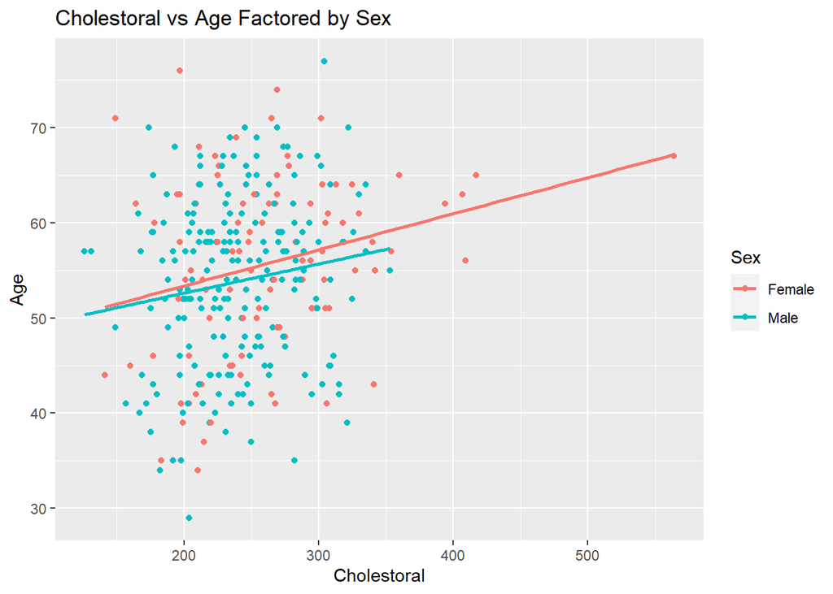

```r
ggplot(Heart, aes(x = Chol, y = Age, color = Sex)) +
  geom_point() +
  labs(x = "Cholestoral", y = "Age", colored = "Sex", title = "Cholestoral vs Age Factored by Sex") +
  geom_smooth(method = "lm", se = FALSE)
```